# Report for Exercise Class

Sachin Gautam

Saturday, December 20, 2014

Problem Statement :

Using devices such as Jawbone Up, Nike FuelBand, and Fitbit it is now possible to collect a large amount of data about personal activity relatively inexpensively. These type of devices are part of the quantified self movement - a group of enthusiasts who take measurements about themselves regularly to improve their health, to find patterns in their behavior, or because they are tech geeks. One thing that people regularly do is quantify how much of a particular activity they do, but they rarely quantify how well they do it. In this project, your goal will be to use data from accelerometers on the belt, forearm, arm, and dumbell of 6 participants. They were asked to perform barbell lifts correctly and incorrectly in 5 different ways. More information is available from the website here: http://groupware.les.inf.puc-rio.br/har (see the section on the Weight Lifting Exercise Dataset).

DATA :

The training data for this project are available here:

https://d396qusza40orc.cloudfront.net/predmachlearn/pml-training.csv

The test data are available here:

https://d396qusza40orc.cloudfront.net/predmachlearn/pml-testing.csv

The data for this project come from this source: http://groupware.les.inf.puc-rio.br/har. If you use the document you create for this class for any purpose please cite them as they have been very generous in allowing their data to be used for this kind of assignment.

In the first step we need to Partition Training Data into trainSet and Validation Set.

```r
set.seed(857)
inTrain <- createDataPartition(pml$classe, p = 0.8, list = FALSE)
trainSet <- pml[inTrain, ]
ValidSet <- pml[-inTrain,]
```

Now we have to fit the data into a model for prediction on test Set. And then we have to go for cross validation using our Training and validation Set. NOw for predicting our model we need to reduce the number of variables so as to avoid overfitting model. We can remove variables which have very small variance (~0). Then we fit randomForest model for training data and then go for cross validation.

So the randomForest model is :

```r
model
```

```
##
## Call:
##  randomForest(formula = classe ~ ., data = Training, importance = TRUE,      ntrees = 10)
##                Type of random forest: classification
##                      Number of trees: 500
## No. of variables tried at each split: 7
##
##         OOB estimate of  error rate: 0.41%
## Confusion matrix:
##      A    B    C    D    E class.error
## A 4461    2    0    0    1 0.000672043
## B   10 3021    7    0    0 0.005595787
## C    0   13 2723    2    0 0.005478451
## D    0    0   21 2550    2 0.008938982
## E    0    0    2    5 2879 0.002425502
```

The contribution of variable to each exercise class is

```r
varImp(model)
```

```
##                             A        B        C        D        E
## roll_belt            38.98024 47.59313 47.51507 46.64512 42.14547
## pitch_belt           33.16532 50.42362 39.85433 35.79888 34.37539
## yaw_belt             46.87308 45.72808 42.13004 44.82656 33.54108
## total_accel_belt     14.83658 17.48774 17.16849 15.72437 15.35383
## gyros_belt_x         20.16968 19.47772 20.12249 15.16675 18.54006
## gyros_belt_y         11.89302 15.68474 17.36511 14.10487 18.75069
## gyros_belt_z         20.57186 27.66729 24.72949 20.95318 26.27852
## accel_belt_x         14.38432 17.99672 17.16987 13.93348 14.68449
## accel_belt_y         11.87042 16.92163 14.88858 15.90450 14.12232
## accel_belt_z         22.32158 27.95889 26.38109 23.00976 21.29122
## magnet_belt_x        19.11307 26.93200 25.73954 22.52155 23.82389
## magnet_belt_y        22.63775 27.06340 26.94509 28.23645 24.05930
## magnet_belt_z        22.73436 26.41000 23.82553 29.52982 23.73654
## roll_arm             21.85816 31.89953 26.64361 28.60137 23.47752
## pitch_arm            15.70946 21.87211 19.74421 19.68629 16.49356
## yaw_arm              22.47170 25.32825 24.12272 27.37715 19.83895
## total_accel_arm      10.17395 21.01313 19.49647 20.50427 21.45154
## gyros_arm_x          17.09972 30.12665 22.93708 23.22570 26.32006
## gyros_arm_y          19.97360 30.70765 27.47608 27.74396 23.95740
## gyros_arm_z          12.26799 19.44540 15.27341 15.67362 14.14848
## accel_arm_x          17.32966 19.67447 19.50986 21.84025 16.25677
## accel_arm_y          18.68362 21.71964 15.95898 18.71515 17.15939
## accel_arm_z          13.20340 23.00687 21.03600 23.58624 21.24936
## magnet_arm_x         17.53863 16.57175 19.76136 18.23605 15.77618
## magnet_arm_y         14.19502 18.56087 18.62015 21.84587 14.38627
## magnet_arm_z         22.20305 27.00355 25.31685 21.18755 20.33725
## roll_dumbbell        25.03489 29.79172 30.84728 28.90171 29.09194
## pitch_dumbbell       12.88430 20.27876 16.62937 12.66422 14.76427
## yaw_dumbbell         20.43492 26.44825 24.13070 21.92081 23.43793
## total_accel_dumbbell 20.67901 25.76514 22.59147 22.18482 25.01728
## gyros_dumbbell_x     17.63503 25.54897 20.58230 20.07626 19.80907
## gyros_dumbbell_y     21.35130 22.57438 26.24110 21.03898 18.88952
## gyros_dumbbell_z     16.54934 23.29928 19.79954 19.67396 16.92438
## accel_dumbbell_x     18.11396 24.50452 21.39465 20.10089 20.45430
## accel_dumbbell_y     27.09099 30.06343 30.84053 27.76009 28.80490
## accel_dumbbell_z     22.93796 29.68885 27.08863 28.42719 28.86599
## magnet_dumbbell_x    25.15161 26.39814 31.49910 27.46710 24.72273
## magnet_dumbbell_y    34.62495 36.37397 44.73615 33.23257 32.70346
## magnet_dumbbell_z    42.12930 40.36404 50.55523 38.45956 37.27202
## roll_forearm         30.63761 26.49099 33.90229 24.85939 25.84582
## pitch_forearm        30.75065 34.67487 36.79801 33.96137 33.72507
## yaw_forearm          19.92284 22.55566 21.08806 21.23444 21.21609
## total_accel_forearm  19.69500 22.36342 20.41573 17.74563 19.30478
## gyros_forearm_x      12.08212 17.96088 20.02198 16.59402 15.31782
## gyros_forearm_y      16.08535 31.14784 26.23350 22.94020 22.16655
## gyros_forearm_z      16.20844 25.94736 23.29025 18.51853 18.29623
## accel_forearm_x      18.58313 25.39962 25.87129 28.29320 22.89828
## accel_forearm_y      20.14809 22.83428 24.67380 20.61231 23.20488
## accel_forearm_z      17.69879 23.43470 24.20916 21.82903 23.39771
## magnet_forearm_x     15.77956 21.60803 20.23872 18.13760 20.95974
## magnet_forearm_y     20.58755 24.56589 25.94286 22.19039 22.19470
## magnet_forearm_z     24.42197 30.15630 26.40144 28.45888 25.91817
```

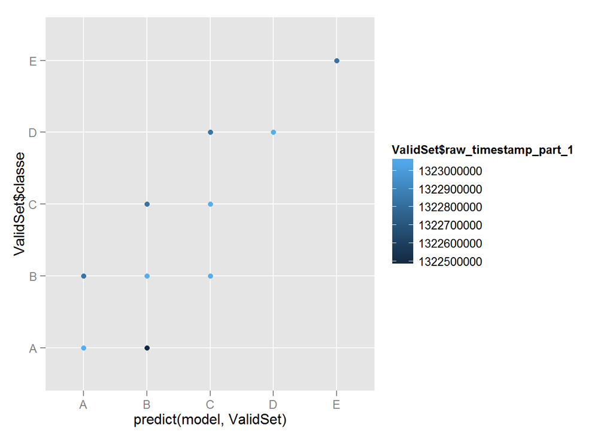

```r
qplot(predict(model,ValidSet),ValidSet$classe,col=ValidSet$raw_timestamp_part_1)
```

```r
print(confusionMatrix(predict(model,trainSet), trainSet$classe))
```

```
## Confusion Matrix and Statistics
##
##           Reference
## Prediction    A    B    C    D    E
##          A 4464    0    0    0    0
##          B    0 3038    0    0    0
##          C    0    0 2738    0    0
##          D    0    0    0 2573    0
##          E    0    0    0    0 2886
##
## Overall Statistics
##
##                Accuracy : 1
##                  95% CI : (0.9998, 1)
##     No Information Rate : 0.2843
##     P-Value [Acc > NIR] : < 2.2e-16
##
##                   Kappa : 1
##  Mcnemar's Test P-Value : NA
##
## Statistics by Class:
##
##                      Class: A Class: B Class: C Class: D Class: E
## Sensitivity            1.0000   1.0000   1.0000   1.0000   1.0000
## Specificity            1.0000   1.0000   1.0000   1.0000   1.0000
## Pos Pred Value         1.0000   1.0000   1.0000   1.0000   1.0000
## Neg Pred Value         1.0000   1.0000   1.0000   1.0000   1.0000
## Prevalence             0.2843   0.1935   0.1744   0.1639   0.1838
## Detection Rate         0.2843   0.1935   0.1744   0.1639   0.1838
## Detection Prevalence   0.2843   0.1935   0.1744   0.1639   0.1838
## Balanced Accuracy      1.0000   1.0000   1.0000   1.0000   1.0000
```

Accuracy Achieved for Validation Set

```r
print(confusionMatrix(predict(model,ValidSet), ValidSet$classe))
```

```
## Confusion Matrix and Statistics
##
##           Reference
## Prediction    A    B    C    D    E
##          A 1115    3    0    0    0
##          B    1  753    7    0    0
##          C    0    3  677    6    0
##          D    0    0    0  637    0
##          E    0    0    0    0  721
##
## Overall Statistics
##
##                Accuracy : 0.9949
##                  95% CI : (0.9921, 0.9969)
##     No Information Rate : 0.2845
##     P-Value [Acc > NIR] : < 2.2e-16
##
##                   Kappa : 0.9936
##  Mcnemar's Test P-Value : NA
##
## Statistics by Class:
##
##                      Class: A Class: B Class: C Class: D Class: E
## Sensitivity            0.9991   0.9921   0.9898   0.9907   1.0000
## Specificity            0.9989   0.9975   0.9972   1.0000   1.0000
## Pos Pred Value         0.9973   0.9895   0.9869   1.0000   1.0000
## Neg Pred Value         0.9996   0.9981   0.9978   0.9982   1.0000
## Prevalence             0.2845   0.1935   0.1744   0.1639   0.1838
## Detection Rate         0.2842   0.1919   0.1726   0.1624   0.1838
## Detection Prevalence   0.2850   0.1940   0.1749   0.1624   0.1838
## Balanced Accuracy      0.9990   0.9948   0.9935   0.9953   1.0000
```

Prediction for Test Set

```r
print(predict(model,testSet));
```

```
##  1  2  3  4  5  6  7  8  9 10 11 12 13 14 15 16 17 18 19 20
##  B  A  B  A  A  E  D  B  A  A  B  C  B  A  E  E  A  B  B  B
## Levels: A B C D E
```